# Modeling - article 1

First, determine the ICC values.

The ICC1 for the total crime index is 0.3099787.  
The ICC1 for the violent crime index is 0.3456869.  
The ICC1 for the property crime index is 0.3136039.  
The ICC1 for the mean NDVI is 0.6860852.

The ICC1 is the proportion of variance in the variable that is attributable to difference between cities. Another way to put it is:  
For the measure of total crime, 31% of the variance in the total crime index is at the city level (Hox, 2010).

### Intercept only model

Run a model with only varying intercepts for the crime variables. This will serve as a base line for further modeling. One model for violent crime and one for property crime.

```r
mod_1a <- lmer(CRMCYPERC ~ 1 + (1|city_st), data = df)
mod_1b <- lmer(CRMCYPROC ~ 1 + (1|city_st), data = df)
screenreg(list(mod_1a, mod_1b))
```

```
========================================================
                          Model 1         Model 2
--------------------------------------------------------
(Intercept)                   146.11 ***      134.81 ***
                               (5.25)          (3.01)
--------------------------------------------------------
AIC                        784590.65       718224.80
BIC                        784617.76       718251.91
Log Likelihood            -392292.32      -359109.40
Num. obs.                   62086           62086
Num. groups: city_st          301             301
Var: city_st (Intercept)     8111.60         2670.64
Var: Residual               17666.65         6067.38
========================================================
*** p < 0.001, ** p < 0.01, * p < 0.05
```

Maybe see what the plot is for these models.

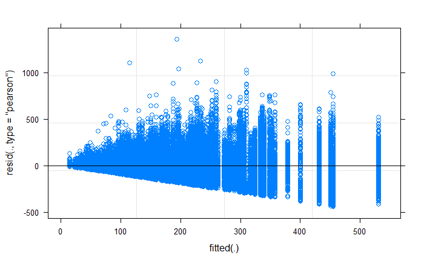

```r
plot(mod_1a)
```

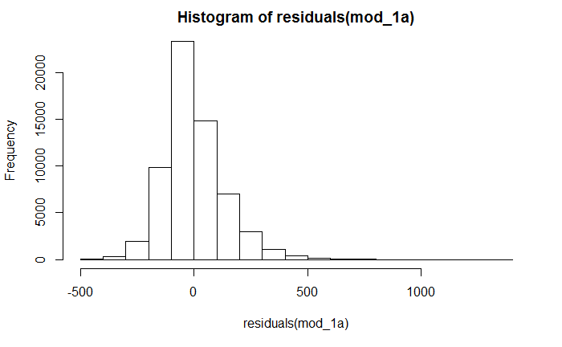

```r
hist(residuals(mod_1a))
```

### Add NDVI (greenspace)

Starting simple we will add NDVI to the model as a varying intercept. The NDVI values are NOT centered.

```r
mod_2a <- lmer(CRMCYPERC ~ ndvi_mean_cbg_adj + (1|city_st), data = df)
mod_2b <- lmer(CRMCYPROC ~ ndvi_mean_cbg_adj + (1|city_st), data = df)
screenreg(list(mod_2a, mod_2b))
```

```
========================================================
                          Model 1         Model 2
--------------------------------------------------------
(Intercept)                   299.47 ***      288.97 ***
                               (6.81)          (4.85)
ndvi_mean_cbg_adj             -35.65 ***      -35.83 ***
                               (0.61)          (0.34)
--------------------------------------------------------
AIC                        781256.90       707949.74
BIC                        781293.04       707985.88
Log Likelihood            -390624.45      -353970.87
Num. obs.                   62086           62086
Num. groups: city_st          301             301
Var: city_st (Intercept)    11755.35         6383.17
Var: Residual               16709.09         5116.35
========================================================
*** p < 0.001, ** p < 0.01, * p < 0.05
```

We can compare these to the intercept only model.

```r
anova(mod_1a, mod_2a)
```

```
refitting model(s) with ML (instead of REML)
```

```
Data: df
Models:
mod_1a: CRMCYPERC ~ 1 + (1 | city_st)
mod_2a: CRMCYPERC ~ ndvi_mean_cbg_adj + (1 | city_st)
       Df    AIC    BIC  logLik deviance  Chisq Chi Df Pr(>Chisq)
mod_1a  3 784596 784623 -392295   784590
mod_2a  4 781263 781299 -390628   781255 3334.5      1  < 2.2e-16 ***
---
Signif. codes:  0 ‘***’ 0.001 ‘**’ 0.01 ‘*’ 0.05 ‘.’ 0.1 ‘ ’ 1
```

```r
anova(mod_1b, mod_2b)
```

```
refitting model(s) with ML (instead of REML)
```

```
Data: df
Models:
mod_1b: CRMCYPROC ~ 1 + (1 | city_st)
mod_2b: CRMCYPROC ~ ndvi_mean_cbg_adj + (1 | city_st)
       Df    AIC    BIC  logLik deviance Chisq Chi Df Pr(>Chisq)
mod_1b  3 718229 718256 -359111   718223
mod_2b  4 707954 707990 -353973   707946 10277      1  < 2.2e-16 ***
---
Signif. codes:  0 ‘***’ 0.001 ‘**’ 0.01 ‘*’ 0.05 ‘.’ 0.1 ‘ ’ 1
```

Unsurprisingly they are better.

How do the residuals look?

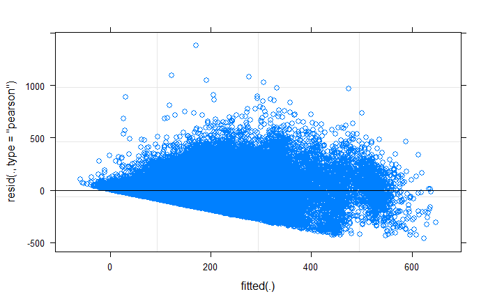

```r
plot(mod_2a)
```

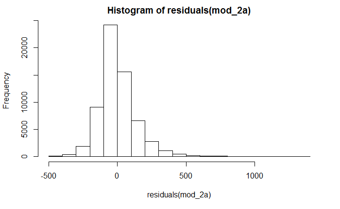

```r
hist(residuals(mod_2a))
```

If we use the grand mean centered NDVI only the intercept would change.

#### NDVI random slope

As we are interested in the relationship between NDVI and crime we can add a varying slope to the model.

```r
mod_2c <- lmer(CRMCYPERC ~ ndvi_mean_cbg_adj + (ndvi_mean_cbg_adj|city_st), data = df)
mod_2d <- lmer(CRMCYPROC ~ ndvi_mean_cbg_adj + (ndvi_mean_cbg_adj|city_st), data = df)
screenreg(list(mod_2c, mod_2d))
```

```
==========================================================================
                                            Model 1         Model 2
--------------------------------------------------------------------------
(Intercept)                                     351.03 ***      343.26 ***
                                                (13.75)         (10.62)
ndvi_mean_cbg_adj                               -45.20 ***      -45.42 ***
                                                 (2.19)          (1.57)
--------------------------------------------------------------------------
AIC                                          777684.64       702335.70
BIC                                          777738.86       702389.92
Log Likelihood                              -388836.32      -351161.85
Num. obs.                                     62086           62086
Num. groups: city_st                            301             301
Var: city_st (Intercept)                      50909.81        32058.00
Var: city_st ndvi_mean_cbg_adj                 1124.64          641.24
Cov: city_st (Intercept) ndvi_mean_cbg_adj    -6536.55        -4142.21
Var: Residual                                 15622.39         4621.75
==========================================================================
*** p < 0.001, ** p < 0.01, * p < 0.05
```

Are these better that the random intercept model?

```r
anova(mod_2a, mod_2c)
```

```
refitting model(s) with ML (instead of REML)
```

```
Data: df
Models:
mod_2a: CRMCYPERC ~ ndvi_mean_cbg_adj + (1 | city_st)
mod_2c: CRMCYPERC ~ ndvi_mean_cbg_adj + (ndvi_mean_cbg_adj | city_st)
       Df    AIC    BIC  logLik deviance  Chisq Chi Df Pr(>Chisq)
mod_2a  4 781263 781299 -390628   781255
mod_2c  6 777694 777748 -388841   777682 3573.5      2  < 2.2e-16 ***
---
Signif. codes:  0 ‘***’ 0.001 ‘**’ 0.01 ‘*’ 0.05 ‘.’ 0.1 ‘ ’ 1
```

```r
anova(mod_2b, mod_2d)
```

```
refitting model(s) with ML (instead of REML)
```

```
Data: df
Models:
mod_2b: CRMCYPROC ~ ndvi_mean_cbg_adj + (1 | city_st)
mod_2d: CRMCYPROC ~ ndvi_mean_cbg_adj + (ndvi_mean_cbg_adj | city_st)
       Df    AIC    BIC  logLik deviance Chisq Chi Df Pr(>Chisq)
mod_2b  4 707954 707990 -353973   707946
mod_2d  6 702343 702397 -351166   702331  5615      2  < 2.2e-16 ***
---
Signif. codes:  0 ‘***’ 0.001 ‘**’ 0.01 ‘*’ 0.05 ‘.’ 0.1 ‘ ’ 1
```

Yes.

At this point we can say that as NDVI increases by 1 (or 0.1 on original scale) the violent crime index will change by -45.2 on average across all cities. The coefficient for NDVI slope across cities has a standard deviation of 33.5.

As NDVI increases by 1 unit the value of ht property crime index changes by -45.4 on average across cities.

Until this point there are no covariates of crime and the NDVI meansure is not centered, so the intercept is the value at NDVI = 0, which is bare rock or water - no very helpful.

### Center NDVI

I will run the previous model with NDVI grand mean centered so that 0 equals the mean NDVI across all block groups in the study.

```r
mod_3a <- lmer(CRMCYPERC ~ gndctr_ndvi_cbg_adj + (1|city_st), data = df)
mod_3b <- lmer(CRMCYPROC ~ gndctr_ndvi_cbg_adj + (1|city_st), data = df)
screenreg(list(mod_3a, mod_3b))
```

```
========================================================
                          Model 1         Model 2
--------------------------------------------------------
(Intercept)                   154.60 ***      143.36 ***
                               (6.29)          (4.62)
gndctr_ndvi_cbg_adj           -35.65 ***      -35.83 ***
                               (0.61)          (0.34)
--------------------------------------------------------
AIC                        781256.90       707949.74
BIC                        781293.04       707985.88
Log Likelihood            -390624.45      -353970.87
Num. obs.                   62086           62086
Num. groups: city_st          301             301
Var: city_st (Intercept)    11755.35         6383.16
Var: Residual               16709.09         5116.35
========================================================
*** p < 0.001, ** p < 0.01, * p < 0.05
```

Everything is the same expect for the intercept.  
Now for the varying slope model.

```r
mod_3c <- lmer(CRMCYPERC ~ gndctr_ndvi_cbg_adj + (gndctr_ndvi_cbg_adj|city_st), data = df)
mod_3d <- lmer(CRMCYPROC ~ gndctr_ndvi_cbg_adj + (gndctr_ndvi_cbg_adj|city_st), data = df)
screenreg(list(mod_3c, mod_3d))
```

```
============================================================================
                                              Model 1         Model 2
----------------------------------------------------------------------------
(Intercept)                                       167.32 ***      158.67 ***
                                                   (7.49)          (5.52)
gndctr_ndvi_cbg_adj                               -45.20 ***      -45.42 ***
                                                   (2.19)          (1.57)
----------------------------------------------------------------------------
AIC                                            777684.64       702335.70
BIC                                            777738.86       702389.92
Log Likelihood                                -388836.32      -351161.85
Num. obs.                                       62086           62086
Num. groups: city_st                              301             301
Var: city_st (Intercept)                        16355.39         8980.72
Var: city_st gndctr_ndvi_cbg_adj                 1124.65          641.24
Cov: city_st (Intercept) gndctr_ndvi_cbg_adj    -1965.95        -1536.21
Var: Residual                                   15622.39         4621.75
============================================================================
*** p < 0.001, ** p < 0.01, * p < 0.05
```

With the uncentered NDVI there was a strong correlation between the slope and the intercept. Now that NDVI is centered is it still there?

```r
tidy(mod_2c)[5, 2]
```

```
[1] -0.8638534
```

```r
tidy(mod_3c)[5, 2]
```

```
[1] -0.4583884
```

```r
tidy(mod_2d)[5, 2]
```

```
[1] -0.913598
```

```r
tidy(mod_3d)[5, 2]
```

```
[1] -0.6401546
```

It has been reduced.

### Level 1 covariates

Now I will add level one covariates tot he model. As the random slope model performed better that the random intercept model I will build off of that. The level 1 varialbes will be grand mean centered so that the intercept will be the crime value when a block group is at the overall average on the variables.

```r
mod_4a <- lmer(CRMCYPERC ~ gndctr_ndvi_cbg_adj + gndctr_MedHHinc000 + gndctr_disad + gndctr_diver + gndctr_U18 + gndctr_logpopden + (gndctr_ndvi_cbg_adj|city_st), data = df_na)
mod_4b <- lmer(CRMCYPROC ~ gndctr_ndvi_cbg_adj + gndctr_MedHHinc000 + gndctr_disad + gndctr_diver + gndctr_U18 + gndctr_logpopden + (gndctr_ndvi_cbg_adj|city_st), data = df_na)
screenreg(list(mod_4a, mod_4b))
```

```
============================================================================
                                              Model 1         Model 2
----------------------------------------------------------------------------
(Intercept)                                       166.05 ***      152.16 ***
                                                   (5.39)          (4.66)
gndctr_ndvi_cbg_adj                               -25.94 ***      -43.49 ***
                                                   (1.79)          (1.41)
gndctr_MedHHinc000                                 -0.40 ***       -0.16 ***
                                                   (0.02)          (0.01)
gndctr_disad                                      100.22 ***       26.77 ***
                                                   (0.85)          (0.52)
gndctr_diver                                      -35.00 ***       22.67 ***
                                                   (2.61)          (1.60)
gndctr_U18                                          0.04           -1.18 ***
                                                   (0.05)          (0.03)
gndctr_logpopden                                  -29.78 ***      -30.23 ***
                                                   (0.57)          (0.35)
----------------------------------------------------------------------------
AIC                                            717459.74       658921.65
BIC                                            717558.70       659020.60
Log Likelihood                                -358718.87      -329449.82
Num. obs.                                       59647           59647
Num. groups: city_st                              301             301
Var: city_st (Intercept)                         8429.06         6403.07
Var: city_st gndctr_ndvi_cbg_adj                  766.89          510.15
Cov: city_st (Intercept) gndctr_ndvi_cbg_adj    -1758.22        -1305.29
Var: Residual                                    9505.99         3543.58
============================================================================
*** p < 0.001, ** p < 0.01, * p < 0.05
```

Are these better than the model without the level 1 covariates?  
Now the model with median income uses fewer cases as some have NA in that variable. The comparison model will need to be refit with a reduced datset.

```r
mod_3e <- lmer(CRMCYPERC ~ gndctr_ndvi_cbg_adj + (gndctr_ndvi_cbg_adj|city_st), data = df_na)
mod_3f <- lmer(CRMCYPROC ~ gndctr_ndvi_cbg_adj + (gndctr_ndvi_cbg_adj|city_st), data = df_na)
anova(mod_3e, mod_4a)
```

```
refitting model(s) with ML (instead of REML)
```

```
Data: df_na
Models:
mod_3e: CRMCYPERC ~ gndctr_ndvi_cbg_adj + (gndctr_ndvi_cbg_adj | city_st)
mod_4a: CRMCYPERC ~ gndctr_ndvi_cbg_adj + gndctr_MedHHinc000 + gndctr_disad +
mod_4a:     gndctr_diver + gndctr_U18 + gndctr_logpopden + (gndctr_ndvi_cbg_adj |
mod_4a:     city_st)
       Df    AIC    BIC  logLik deviance Chisq Chi Df Pr(>Chisq)
mod_3e  6 744950 745004 -372469   744938
mod_4a 11 717462 717561 -358720   717440 27497      5  < 2.2e-16 ***
---
Signif. codes:  0 ‘***’ 0.001 ‘**’ 0.01 ‘*’ 0.05 ‘.’ 0.1 ‘ ’ 1
```

```r
anova(mod_3f, mod_4b)
```

```
refitting model(s) with ML (instead of REML)
```

```
Data: df_na
Models:
mod_3f: CRMCYPROC ~ gndctr_ndvi_cbg_adj + (gndctr_ndvi_cbg_adj | city_st)
mod_4b: CRMCYPROC ~ gndctr_ndvi_cbg_adj + gndctr_MedHHinc000 + gndctr_disad +
mod_4b:     gndctr_diver + gndctr_U18 + gndctr_logpopden + (gndctr_ndvi_cbg_adj |
mod_4b:     city_st)
       Df    AIC    BIC  logLik deviance Chisq Chi Df Pr(>Chisq)
mod_3f  6 670800 670854 -335394   670788
mod_4b 11 658919 659017 -329448   658897 11891      5  < 2.2e-16 ***
---
Signif. codes:  0 ‘***’ 0.001 ‘**’ 0.01 ‘*’ 0.05 ‘.’ 0.1 ‘ ’ 1
```

The models with level 1 covariates fit the data better at $\chi^2$=27497, df=5, p<0.001

At this point let’s see what reduction in variance we have acheived.

In the violent crime intercept only model the Residual variance = 17666.65  
Adding NDVI as a random intercept Residual variance = 16709.09  
Adding NDVI as a random slope Residual variance = 15622.39  
With level 1 covariates Residual variance = 9505.99

Variance in the intercept with the violent crime:  
Intercept only = 8111.60  
NDVI intercept = 11755.35 (non-centered) NDVI slope = 50909.81 (non-centered)  
NDVI slope = 16355.39 (centered)  
Level 1 covariates = 8429.06

Adding NDVI as a random intercept reduced residual variance 5.42%. Adding a random slope for NDVI reduced the residual variance 6.5% from a model with only a random intercept for NDVI. Then adding level 1 covariates reduces the residual variance a further 39.15%. From the intercept only model to the level 1 covariate model residual variance was decreased 46.19%.

### Level 2 covariates

There are variables measured at the level of the city and we want to know if they influence crime. We will continue with the random slope version.

```r
mod_5a <- lmer(CRMCYPERC ~ gndctr_ndvi_cbg_adj + gndctr_MedHHinc000 + gndctr_disad + gndctr_diver + gndctr_U18 + gndctr_logpopden + gndctr_Police + gndctr_rt_violent + clust4 + PCgdp15 + (gndctr_ndvi_cbg_adj|city_st), data = df_na)
```

```
Some predictor variables are on very different scales: consider rescaling
```

```r
mod_5b <- lmer(CRMCYPROC ~ gndctr_ndvi_cbg_adj + gndctr_MedHHinc000 + gndctr_disad + gndctr_diver + gndctr_U18 + gndctr_logpopden + gndctr_Police + gndctr_rt_property + clust4 + PCgdp15 +(gndctr_ndvi_cbg_adj|city_st), data = df_na)
```

```
Some predictor variables are on very different scales: consider rescaling
```

```r
screenreg(list(mod_5a, mod_5b))
```

```
============================================================================
                                              Model 1         Model 2
----------------------------------------------------------------------------
(Intercept)                                       122.94 ***      115.38 ***
                                                  (10.39)          (8.93)
gndctr_ndvi_cbg_adj                               -28.56 ***      -44.97 ***
                                                   (1.66)          (1.34)
gndctr_MedHHinc000                                 -0.39 ***       -0.16 ***
                                                   (0.02)          (0.01)
gndctr_disad                                       99.93 ***       26.78 ***
                                                   (0.85)          (0.52)
gndctr_diver                                      -34.53 ***       23.01 ***
                                                   (2.61)          (1.60)
gndctr_U18                                          0.05           -1.18 ***
                                                   (0.05)          (0.03)
gndctr_logpopden                                  -29.99 ***      -30.32 ***
                                                   (0.57)          (0.35)
gndctr_Police                                       3.43            3.82
                                                   (3.53)          (2.73)
gndctr_rt_violent                                  15.65 ***
                                                   (0.79)
clust4cool_wet                                     57.48 ***       94.77 ***
                                                   (7.33)          (6.21)
clust4warm_wet                                     33.91 ***       74.67 ***
                                                   (7.47)          (6.28)
clust4cool_dry                                     43.23 ***       67.70 ***
                                                   (7.39)          (6.27)
PCgdp15                                             0.00 ***       -0.00 *
                                                   (0.00)          (0.00)
gndctr_rt_property                                                  2.38 ***
                                                                   (0.16)
----------------------------------------------------------------------------
AIC                                            717127.31       658586.91
BIC                                            717280.24       658739.84
Log Likelihood                                -358546.65      -329276.45
Num. obs.                                       59647           59647
Num. groups: city_st                              301             301
Var: city_st (Intercept)                         2163.72         1758.33
Var: city_st gndctr_ndvi_cbg_adj                  614.55          453.41
Cov: city_st (Intercept) gndctr_ndvi_cbg_adj     -751.71         -575.10
Var: Residual                                    9516.68         3544.07
============================================================================
*** p < 0.001, ** p < 0.01, * p < 0.05
```

Are these better than the model with just level 1 covariates?

```r
anova(mod_4a, mod_5a)
```

```
refitting model(s) with ML (instead of REML)
```

```
Data: df_na
Models:
mod_4a: CRMCYPERC ~ gndctr_ndvi_cbg_adj + gndctr_MedHHinc000 + gndctr_disad +
mod_4a:     gndctr_diver + gndctr_U18 + gndctr_logpopden + (gndctr_ndvi_cbg_adj |
mod_4a:     city_st)
mod_5a: CRMCYPERC ~ gndctr_ndvi_cbg_adj + gndctr_MedHHinc000 + gndctr_disad +
mod_5a:     gndctr_diver + gndctr_U18 + gndctr_logpopden + gndctr_Police +
mod_5a:     gndctr_rt_violent + clust4 + PCgdp15 + (gndctr_ndvi_cbg_adj |
mod_5a:     city_st)
       Df    AIC    BIC  logLik deviance  Chisq Chi Df Pr(>Chisq)
mod_4a 11 717462 717561 -358720   717440
mod_5a 17 717134 717287 -358550   717100 340.13      6  < 2.2e-16 ***
---
Signif. codes:  0 ‘***’ 0.001 ‘**’ 0.01 ‘*’ 0.05 ‘.’ 0.1 ‘ ’ 1
```

```r
anova(mod_4b, mod_5b)
```

```
refitting model(s) with ML (instead of REML)
```

```
Data: df_na
Models:
mod_4b: CRMCYPROC ~ gndctr_ndvi_cbg_adj + gndctr_MedHHinc000 + gndctr_disad +
mod_4b:     gndctr_diver + gndctr_U18 + gndctr_logpopden + (gndctr_ndvi_cbg_adj |
mod_4b:     city_st)
mod_5b: CRMCYPROC ~ gndctr_ndvi_cbg_adj + gndctr_MedHHinc000 + gndctr_disad +
mod_5b:     gndctr_diver + gndctr_U18 + gndctr_logpopden + gndctr_Police +
mod_5b:     gndctr_rt_property + clust4 + PCgdp15 + (gndctr_ndvi_cbg_adj |
mod_5b:     city_st)
       Df    AIC    BIC  logLik deviance  Chisq Chi Df Pr(>Chisq)
mod_4b 11 658919 659017 -329448   658897
mod_5b 17 658584 658737 -329275   658550 346.86      6  < 2.2e-16 ***
---
Signif. codes:  0 ‘***’ 0.001 ‘**’ 0.01 ‘*’ 0.05 ‘.’ 0.1 ‘ ’ 1
```

Yes.

The previous model used a categorical variable for the climate region. I can use temperature and precipitation too, let’s give it a go.

```r
mod_5c <- lmer(CRMCYPERC ~ gndctr_ndvi_cbg_adj + gndctr_MedHHinc000 + gndctr_disad + gndctr_diver + gndctr_U18 + gndctr_logpopden + gndctr_Police + gndctr_rt_violent + PCgdp15 + city_t_mean + city_p_mean  + (gndctr_ndvi_cbg_adj|city_st), data = df_na)
```

```
Some predictor variables are on very different scales: consider rescaling
```

```r
mod_5d <- lmer(CRMCYPROC ~ gndctr_ndvi_cbg_adj + gndctr_MedHHinc000 + gndctr_disad + gndctr_diver + gndctr_U18 + gndctr_logpopden + gndctr_Police + gndctr_rt_property + PCgdp15 + city_t_mean + city_p_mean  +(gndctr_ndvi_cbg_adj|city_st), data = df_na)
```

```
Some predictor variables are on very different scales: consider rescaling
```

```r
screenreg(list(mod_5c, mod_5d))
```

```
============================================================================
                                              Model 1         Model 2
----------------------------------------------------------------------------
(Intercept)                                       152.74 ***      144.67 ***
                                                  (14.80)         (12.46)
gndctr_ndvi_cbg_adj                               -28.51 ***      -44.89 ***
                                                   (1.66)          (1.34)
gndctr_MedHHinc000                                 -0.39 ***       -0.16 ***
                                                   (0.02)          (0.01)
gndctr_disad                                       99.85 ***       26.70 ***
                                                   (0.85)          (0.52)
gndctr_diver                                      -34.73 ***       22.78 ***
                                                   (2.61)          (1.59)
gndctr_U18                                          0.05           -1.18 ***
                                                   (0.05)          (0.03)
gndctr_logpopden                                  -29.96 ***      -30.30 ***
                                                   (0.57)          (0.35)
gndctr_Police                                       1.41            0.11
                                                   (3.65)          (2.79)
gndctr_rt_violent                                  15.54 ***
                                                   (0.80)
PCgdp15                                             0.00 ***       -0.00 **
                                                   (0.00)          (0.00)
city_t_mean                                        -2.69 ***       -3.42 ***
                                                   (0.56)          (0.47)
city_p_mean                                         0.05 ***        0.09 ***
                                                   (0.01)          (0.01)
gndctr_rt_property                                                  2.37 ***
                                                                   (0.16)
----------------------------------------------------------------------------
AIC                                            717154.51       658607.70
BIC                                            717298.45       658751.64
Log Likelihood                                -358561.25      -329287.85
Num. obs.                                       59647           59647
Num. groups: city_st                              301             301
Var: city_st (Intercept)                         2141.77         1818.60
Var: city_st gndctr_ndvi_cbg_adj                  614.63          449.83
Cov: city_st (Intercept) gndctr_ndvi_cbg_adj     -726.16         -614.15
Var: Residual                                    9516.51         3544.60
============================================================================
*** p < 0.001, ** p < 0.01, * p < 0.05
```

The police variable is not significant so we will drop it and run again.

```r
mod_5e <- lmer(CRMCYPERC ~ gndctr_ndvi_cbg_adj + gndctr_MedHHinc000 + gndctr_disad + gndctr_diver + gndctr_U18 + gndctr_logpopden + gndctr_rt_violent + PCgdp15 + city_t_mean + city_p_mean  + (gndctr_ndvi_cbg_adj|city_st), data = df_na)
```

```
Some predictor variables are on very different scales: consider rescaling
```

```r
mod_5f <- lmer(CRMCYPROC ~ gndctr_ndvi_cbg_adj + gndctr_MedHHinc000 + gndctr_disad + gndctr_diver + gndctr_U18 + gndctr_logpopden  + gndctr_rt_property + PCgdp15 + city_t_mean + city_p_mean  +(gndctr_ndvi_cbg_adj|city_st), data = df_na)
```

```
Some predictor variables are on very different scales: consider rescaling
```

```r
screenreg(list(mod_5e, mod_5f))
```

```
============================================================================
                                              Model 1         Model 2
----------------------------------------------------------------------------
(Intercept)                                       151.15 ***      144.54 ***
                                                  (13.89)         (11.81)
gndctr_ndvi_cbg_adj                               -28.49 ***      -44.89 ***
                                                   (1.66)          (1.34)
gndctr_MedHHinc000                                 -0.39 ***       -0.16 ***
                                                   (0.02)          (0.01)
gndctr_disad                                       99.85 ***       26.70 ***
                                                   (0.85)          (0.52)
gndctr_diver                                      -34.74 ***       22.78 ***
                                                   (2.61)          (1.59)
gndctr_U18                                          0.05           -1.18 ***
                                                   (0.05)          (0.03)
gndctr_logpopden                                  -29.96 ***      -30.30 ***
                                                   (0.57)          (0.35)
gndctr_rt_violent                                  15.75 ***
                                                   (0.68)
PCgdp15                                             0.00 ***       -0.00 **
                                                   (0.00)          (0.00)
city_t_mean                                        -2.72 ***       -3.43 ***
                                                   (0.56)          (0.46)
city_p_mean                                         0.05 ***        0.09 ***
                                                   (0.01)          (0.01)
gndctr_rt_property                                                  2.37 ***
                                                                   (0.15)
----------------------------------------------------------------------------
AIC                                            717157.07       658609.59
BIC                                            717292.01       658744.54
Log Likelihood                                -358563.53      -329289.80
Num. obs.                                       59647           59647
Num. groups: city_st                              301             301
Var: city_st (Intercept)                         2114.72         1812.71
Var: city_st gndctr_ndvi_cbg_adj                  615.18          449.72
Cov: city_st (Intercept) gndctr_ndvi_cbg_adj     -716.53         -613.56
Var: Residual                                    9516.55         3544.61
============================================================================
*** p < 0.001, ** p < 0.01, * p < 0.05
```

#### marginal plots

```
Computing p-values via Wald-statistics approximation (treating t as Wald z).
```

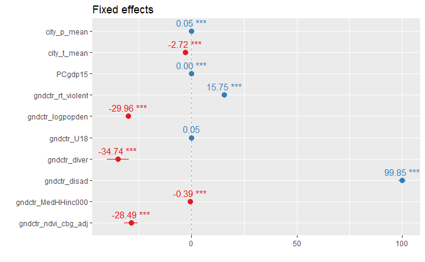

```r
sjp.lmer(mod_5e, type = "fe", p.kr = FALSE, y.offset = 0.4)
```

#### Relationship investigation

So some cities can have a positive relationship between NDVI and crime, let’s look at those.

```r
preds <- ranef(mod_5e)$city_st
preds$city_st <- row.names(preds)
mean(preds$gndctr_ndvi_cbg_adj)
```

```
[1] -2.884625e-12
```

```r
sd(preds$gndctr_ndvi_cbg_adj)
```

```
[1] 22.2474
```

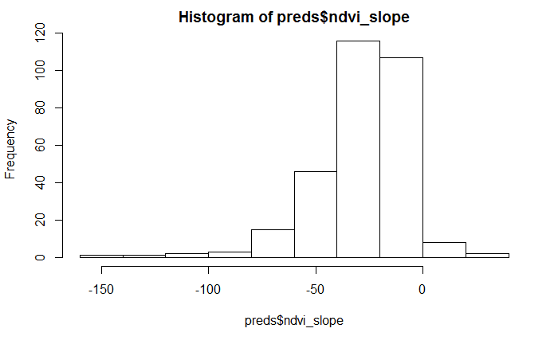

```r
preds$ndvi_slope <- -28.49 + preds$gndctr_ndvi_cbg_adj
hist(preds$ndvi_slope)
```

```r
preds$p.int <- 151.15 + preds$`(Intercept)`
pos_city <- preds %>% filter(ndvi_slope > 0)
pos_city %>% dplyr::select(city_st, ndvi_slope, p.int) %>% arrange(desc(ndvi_slope))
```

| city_st | ndvi_slope | p.int |
| --- | --- | --- |
| Detroit_MI | 28.808400 | 142.10440 |
| Newark_NJ | 20.949747 | 130.07064 |
| Santa Ana_CA | 12.481254 | 130.97317 |
| Chicago_IL | 11.252236 | 130.30919 |
| Hialeah_FL | 7.736622 | 84.13156 |
| Pompano Beach_FL | 5.639691 | 112.49012 |
| Midland_TX | 2.388490 | 94.43790 |
| Naperville_IL | 2.078215 | 137.07322 |
| Westminster_CO | 1.475875 | 139.18489 |
| Fresno_CA | 1.068765 | 124.79466 |

and who are the ones with the strongest negative relationship at this point?

```r
preds %>% arrange(ndvi_slope) %>% slice(1:10) %>% dplyr::select(city_st, ndvi_slope, p.int)
```

| city_st | ndvi_slope | p.int |
| --- | --- | --- |
| Little Rock_AR | -153.27579 | 429.8750 |
| Springfield_IL | -131.46709 | 390.4737 |
| Oakland_CA | -118.44835 | 149.0336 |
| Nashville_TN | -101.13866 | 342.6086 |
| Indianapolis_IN | -96.24080 | 265.3170 |
| Stockton_CA | -89.53262 | 153.8583 |
| Wichita_KS | -87.71864 | 222.7491 |
| Spokane_WA | -79.99393 | 204.3999 |
| Worcester_MA | -79.60401 | 258.5191 |
| Rockford_IL | -79.57840 | 225.2244 |

```r
cor.test(preds$ndvi_slope, preds$p.int)
```

```
    Pearson's product-moment correlation

data:  preds$ndvi_slope and preds$p.int
t = -16.649, df = 299, p-value < 2.2e-16
alternative hypothesis: true correlation is not equal to 0
95 percent confidence interval:
 -0.7479903 -0.6299311
sample estimates:
       cor
-0.6935893
```

A plot of these slopes would be…

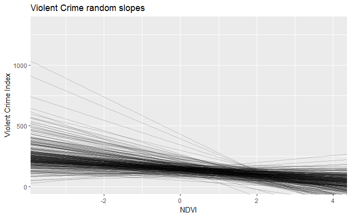

```r
df_na %>% ggplot(aes(gndctr_ndvi_cbg_adj, CRMCYPERC)) + geom_point(alpha = 0) + geom_abline(aes(slope=ndvi_slope, intercept=p.int), data = preds, alpha = .2) + labs(x = "NDVI", y = "Violent Crime Index", title = "Violent Crime random slopes")
```

and look at the residuals of the last model.

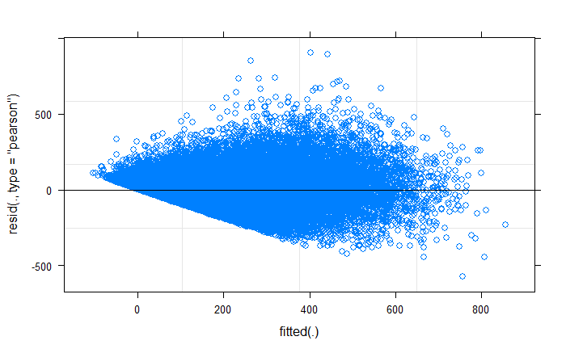

```r
plot(mod_5e)
```

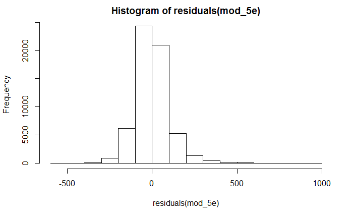

```r
hist(residuals(mod_5e))
```

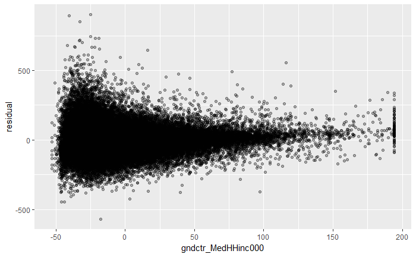

```r
rdf <- mod_5e@frame %>% mutate(rsd = residuals(mod_5e))
rdf %>% ggplot(aes(gndctr_MedHHinc000, rsd)) + geom_point(alpha = .3) + labs(y="residual")
```

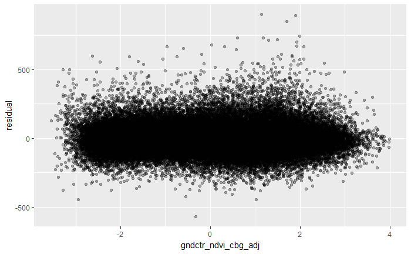

```r
rdf %>% ggplot(aes(gndctr_ndvi_cbg_adj, rsd)) + geom_point(alpha = .3) + labs(y="residual")
```

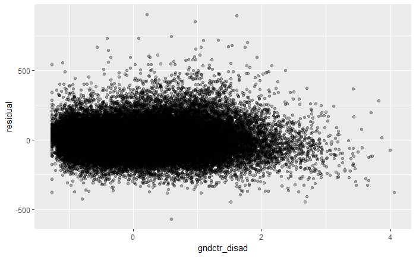

```r
rdf %>% ggplot(aes(gndctr_disad, rsd)) + geom_point(alpha = .3) + labs(y="residual")
```

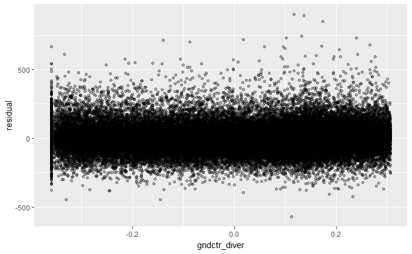

```r
rdf %>% ggplot(aes(gndctr_diver, rsd)) + geom_point(alpha = .3) + labs(y="residual")
```

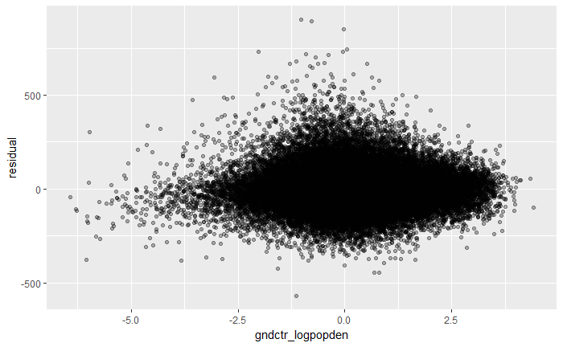

```r
rdf %>% ggplot(aes(gndctr_logpopden, rsd)) + geom_point(alpha = .3) + labs(y="residual")
```